# IE582 Fall

Homework 3

Fatma Nur Dumlupınar

01 01 2021

```r
library(dplyr)
library(tidyverse)
library(glmnet)
library(Matrix)
library(MLmetrics)
library(penalized)
library(ggplot2)

ElectricityConsumption<-read.csv("data/GercekZamanliTuketim-01012016-01122020.csv",sep=",")

ElectricityConsumption<-ElectricityConsumption%>%
  rename(Date=Tarih, Hour=Saat,Consumption_MWh="Tüketim.Miktarı..MWh.")%>%
  mutate(DateTime=as.POSIXct(paste(Date, Hour), format="%d.%m.%Y %H:%M"),
         Date=as.Date(Date,format="%d.%m.%Y"))

ElectricityConsumption$Consumption_MWh=as.numeric(gsub("\\,",".",gsub("\\.", "", ElectricityConsumption$Consumption_MWh)))
```

# 1 PART A

## 1.1 Naive Approaches

```r
lag_48<-lag(ElectricityConsumption$Consumption_MWh,n=48)
lag_168<-lag(ElectricityConsumption$Consumption_MWh,n=168)

ElectricityConsumption_longf<-cbind(ElectricityConsumption,lag_48,lag_168)

ConsumptionTest_LongF<-ElectricityConsumption_longf%>%
  filter(Date>= as.Date("2020-11-01"))

ConsumptionTrain_LongF<-ElectricityConsumption_longf%>%
  filter(Date< as.Date("2020-11-01"))%>%
  filter(Date!=as.Date("2016-03-27"))
```

There are 42384 hourly instances in the data. However, since the first lagged values are NA, the first 168 rows are not considered in the models. That is, models will be established using 42216 instances.

**Lag 48**

```r
print(paste("MAPE of naive approach with lag 48: " ,MAPE(ConsumptionTest_LongF$Consumption_MWh,ConsumptionTest_LongF$lag_48 )))
```

```
## [1] "MAPE of naive approach with lag 48:  0.0818808509914842"
```

```r
MAPE_naive48<-MAPE(ConsumptionTest_LongF$Consumption_MWh,ConsumptionTest_LongF$lag_48 )

actual<-ConsumptionTest_LongF$Consumption_MWh
residual<-ConsumptionTest_LongF$Consumption_MWh-ConsumptionTest_LongF$lag_48
AbsPercError_48<-abs(residual/actual)
print("Summary of Absolute Percentage Errors for the naive approach with lag 48:")
```

```
## [1] "Summary of Absolute Percentage Errors for the naive approach with lag 48:"
```

```r
print(summary(AbsPercError_48))
```

```
##      Min.   1st Qu.    Median      Mean   3rd Qu.      Max.
## 0.0000955 0.0164348 0.0572972 0.0806031 0.1010699 0.4377075
```

**Lag 168**

```r
print(paste("MAPE of naive approach with lag 168: " ,MAPE(ConsumptionTest_LongF$Consumption_MWh,ConsumptionTest_LongF$lag_168 )))
```

```
## [1] "MAPE of naive approach with lag 168:  0.0365111250910964"
```

```r
MAPE_naive168<-MAPE(ConsumptionTest_LongF$Consumption_MWh,ConsumptionTest_LongF$lag_168 )

actual<-ConsumptionTest_LongF$Consumption_MWh
residual<-ConsumptionTest_LongF$Consumption_MWh-ConsumptionTest_LongF$lag_168
AbsPercError_168<-abs(residual/actual)
print("Summary of Absolute Percentage Errors for the naive approach with lag 168:")
```

```
## [1] "Summary of Absolute Percentage Errors for the naive approach with lag 168:"
```

```r
print(summary(AbsPercError_168))
```

```
##      Min.   1st Qu.    Median      Mean   3rd Qu.      Max.
## 8.521e-05 1.336e-02 2.514e-02 3.449e-02 4.549e-02 1.957e-01
```

In the prediction of the next day, the data of the previous week gives a better result than the data of two days ago because the MAPE of lag 168 is visibly less than the MAPE of lag 48.

# 2 PART B

## 2.1 Linear Regression

```r
fit_lreg=lm(Consumption_MWh~lag_48+lag_168,ConsumptionTrain_LongF[169:42384,c(3,5,6)])
summary(fit_lreg)
```

```
##
## Call:
## lm(formula = Consumption_MWh ~ lag_48 + lag_168, data = ConsumptionTrain_LongF[169:42384,
##     c(3, 5, 6)])
##
## Residuals:
##      Min       1Q   Median       3Q      Max
## -17122.0   -985.1     -1.4   1016.1  16097.6
##
## Coefficients:
##              Estimate Std. Error t value Pr(>|t|)
## (Intercept) 1.585e+03  8.346e+01   18.99   <2e-16 ***
## lag_48      3.085e-01  3.093e-03   99.74   <2e-16 ***
## lag_168     6.431e-01  3.091e-03  208.04   <2e-16 ***
## ---
## Signif. codes:  0 '***' 0.001 '**' 0.01 '*' 0.05 '.' 0.1 ' ' 1
##
## Residual standard error: 2389 on 42189 degrees of freedom
##   (24 observations deleted due to missingness)
## Multiple R-squared:  0.7755, Adjusted R-squared:  0.7755
## F-statistic: 7.288e+04 on 2 and 42189 DF,  p-value: < 2.2e-16
```

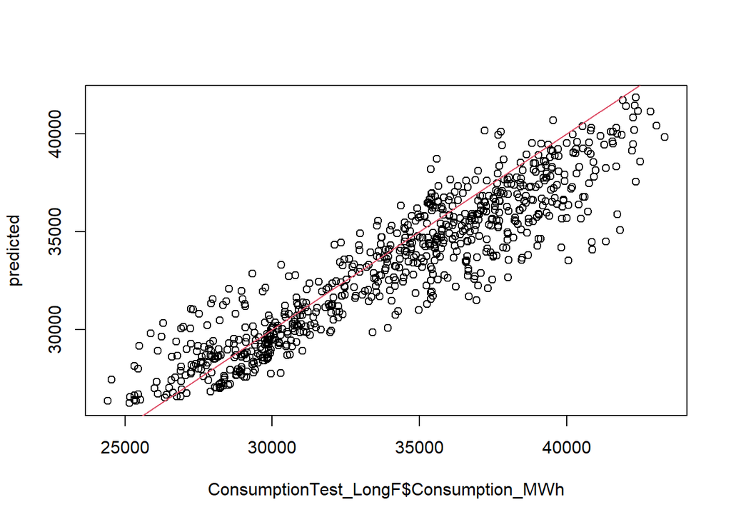

```r
predicted=predict(fit_lreg,ConsumptionTest_LongF)
plot(ConsumptionTest_LongF$Consumption_MWh,predicted)
abline(a=0,b=1,col=2)
```

```r
MAPE_lreg_full<-MAPE(ConsumptionTest_LongF$Consumption_MWh,predicted)
print(paste("MAPE of the linear regression is:" ,MAPE_lreg_full))
```

```
## [1] "MAPE of the linear regression is: 0.0439325970208872"
```

```r
actual<-ConsumptionTest_LongF$Consumption_MWh
residual<-ConsumptionTest_LongF$Consumption_MWh-predicted
AbsPercError_lreg_full<-abs(residual/actual)
print("Summary of Absolute Percentage Errors for the linear regression")
```

```
## [1] "Summary of Absolute Percentage Errors for the linear regression"
```

```r
print(summary(AbsPercError_lreg_full))
```

```
##      Min.   1st Qu.    Median      Mean   3rd Qu.      Max.
## 0.0001062 0.0182664 0.0330648 0.0422983 0.0570356 0.1661142
```

In the linear regression model, both variables turned out to be significant as expected. The MAPE of the model is slightly higher than the one resulting from naive approach with the lag 168, although it is considerably less than the error coming from lag 48.

# 3 PART C

## 3.1 Linear Regression on hourly basis

Previously, only one linear regression model was created using all the data. This time the dataset will be divided into hourly zones and a linear regression model will be created for each hour. In this way, errors due to hourly seasonality can be overcome.

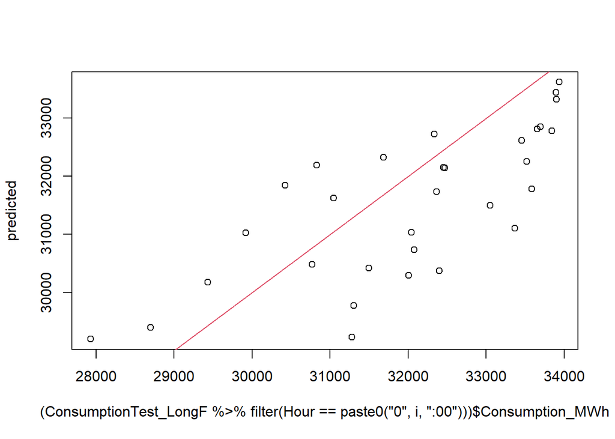

```
## [1] "MAPE of the linear regression for hour 0 is: 0.0334320659973724"
## [1] "Summary of Absolute Percentage Errors for the linear regression when Hour is equal to 0 :"
##    Min. 1st Qu.  Median    Mean 3rd Qu.    Max.
## 0.00912 0.01898 0.03138 0.03263 0.04610 0.06772
```

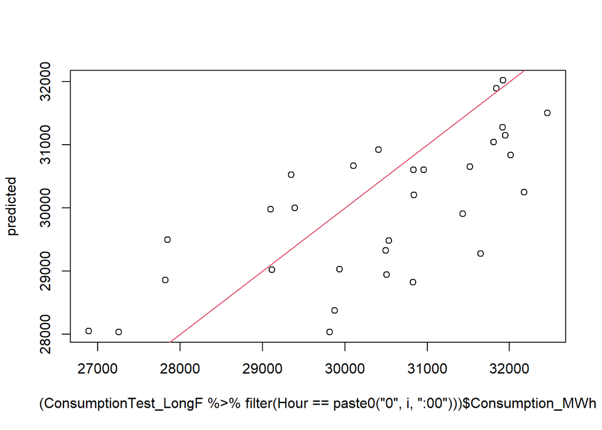

```
## [1] "MAPE of the linear regression for hour 1 is: 0.0336210033922898"
## [1] "Summary of Absolute Percentage Errors for the linear regression when Hour is equal to 1 :"
##     Min.  1st Qu.   Median     Mean  3rd Qu.     Max.
## 0.001606 0.020255 0.030201 0.032830 0.045861 0.074915
```

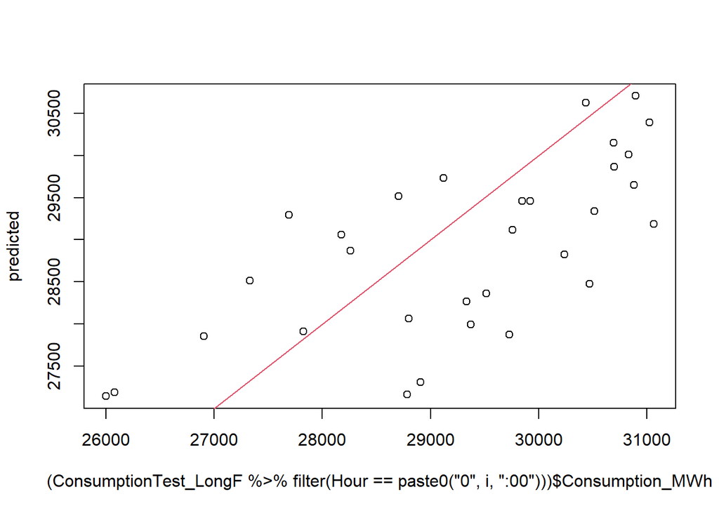

```
## [1] "MAPE of the linear regression for hour 2 is: 0.0347671361034005"
## [1] "Summary of Absolute Percentage Errors for the linear regression when Hour is equal to 2 :"
##     Min.  1st Qu.   Median     Mean  3rd Qu.     Max.
## 0.002961 0.021277 0.035406 0.034077 0.045416 0.065623
```

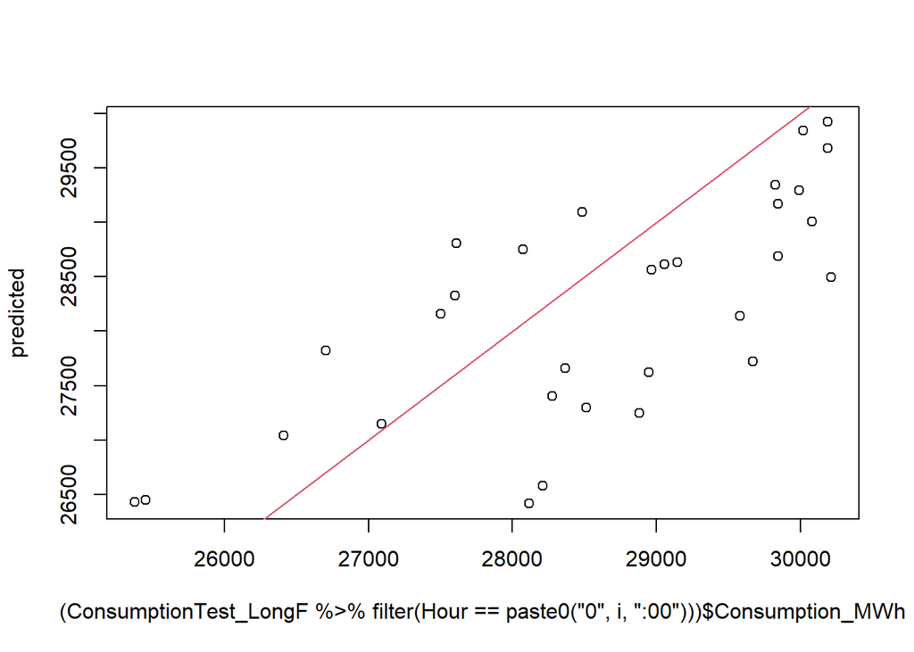

```
## [1] "MAPE of the linear regression for hour 3 is: 0.0327693407487704"
## [1] "Summary of Absolute Percentage Errors for the linear regression when Hour is equal to 3 :"
##     Min.  1st Qu.   Median     Mean  3rd Qu.     Max.
## 0.002056 0.019412 0.026455 0.032027 0.043031 0.065774
```

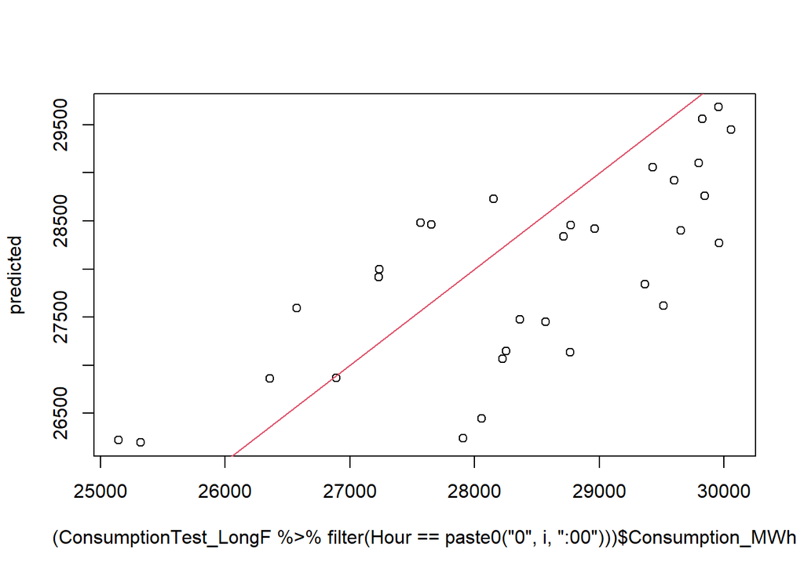

```
## [1] "MAPE of the linear regression for hour 4 is: 0.0326257547967249"
## [1] "Summary of Absolute Percentage Errors for the linear regression when Hour is equal to 4 :"
##      Min.   1st Qu.    Median      Mean   3rd Qu.      Max.
## 0.0007256 0.0195113 0.0314478 0.0318302 0.0416742 0.0642265
```

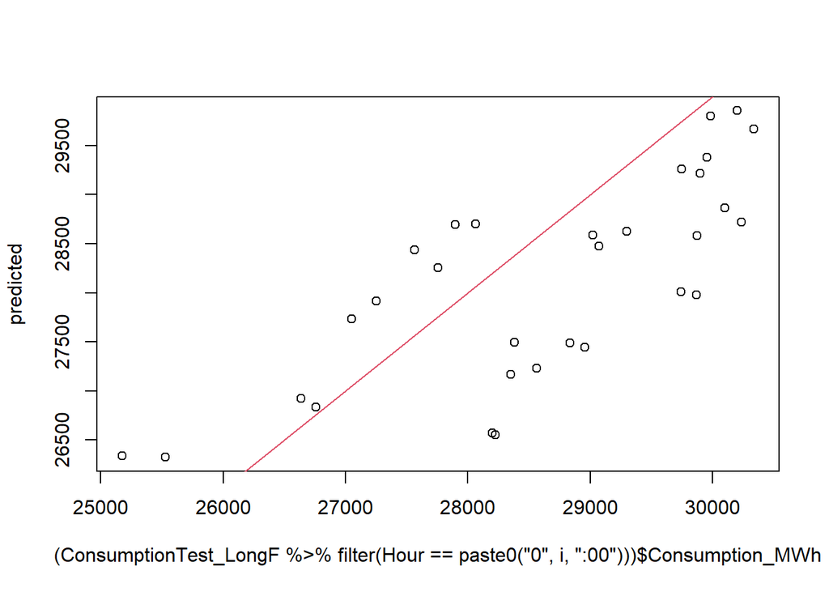

```
## [1] "MAPE of the linear regression for hour 5 is: 0.0327767085435739"
## [1] "Summary of Absolute Percentage Errors for the linear regression when Hour is equal to 5 :"
##     Min.  1st Qu.   Median     Mean  3rd Qu.     Max.
## 0.002747 0.019875 0.028519 0.031877 0.046308 0.063263
```

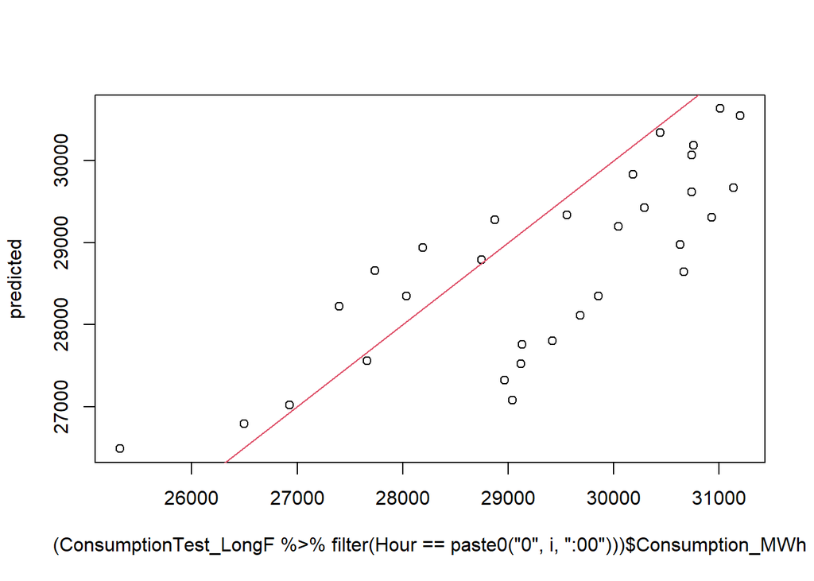

```
## [1] "MAPE of the linear regression for hour 6 is: 0.0326285260487115"
## [1] "Summary of Absolute Percentage Errors for the linear regression when Hour is equal to 6 :"
##     Min.  1st Qu.   Median     Mean  3rd Qu.     Max.
## 0.001491 0.012055 0.028689 0.031486 0.051670 0.067613
```

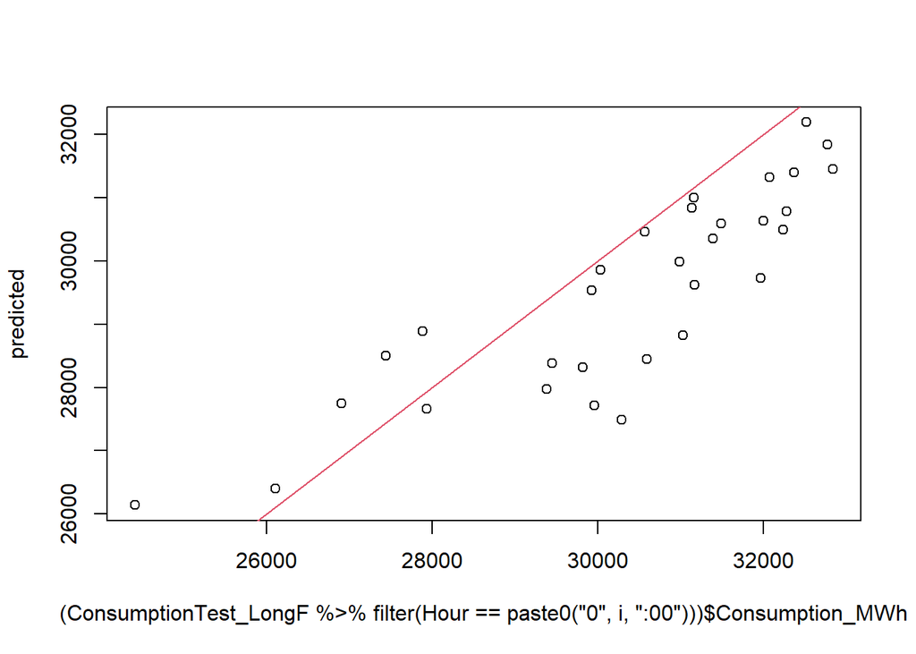

```
## [1] "MAPE of the linear regression for hour 7 is: 0.0392964963498246"
## [1] "Summary of Absolute Percentage Errors for the linear regression when Hour is equal to 7 :"
##     Min.  1st Qu.   Median     Mean  3rd Qu.     Max.
## 0.003491 0.018388 0.035958 0.037771 0.049995 0.092569
```

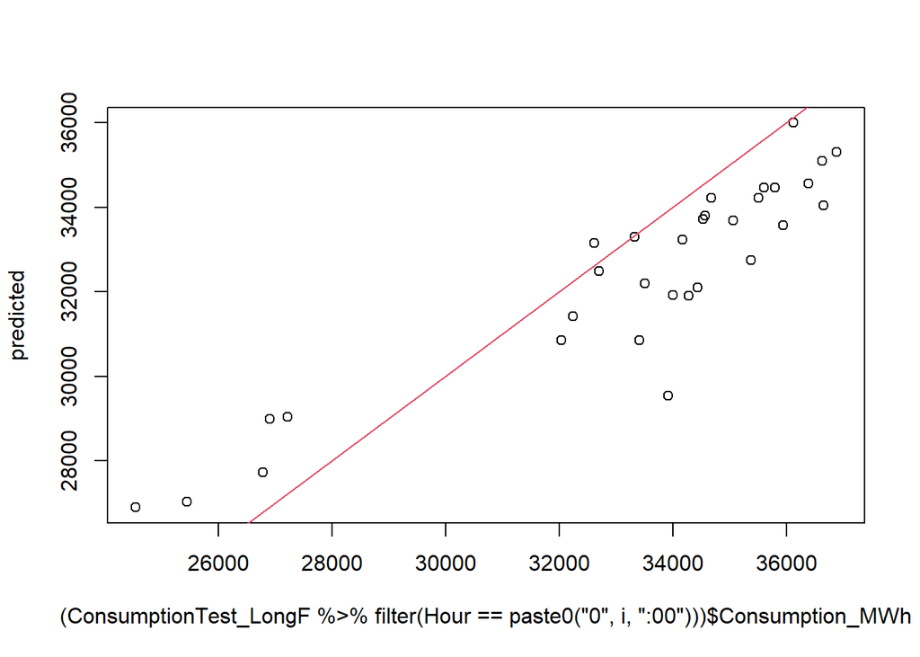

```
## [1] "MAPE of the linear regression for hour 8 is: 0.0483649987818386"
## [1] "Summary of Absolute Percentage Errors for the linear regression when Hour is equal to 8 :"
##      Min.   1st Qu.    Median      Mean   3rd Qu.      Max.
## 0.0006358 0.0266402 0.0393978 0.0467472 0.0672539 0.1290449
```

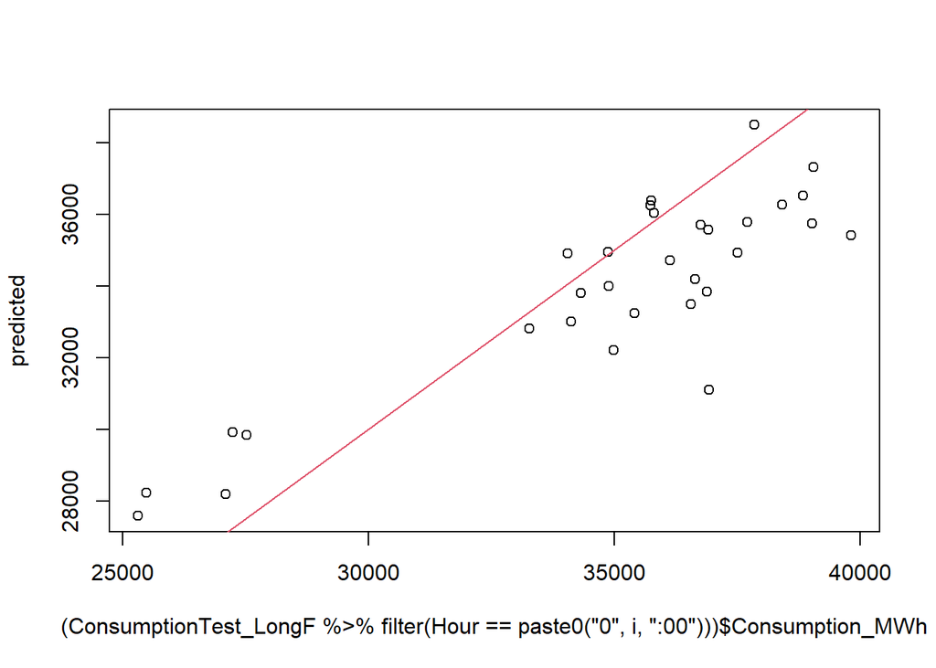

```
## [1] "MAPE of the linear regression for hour 9 is: 0.0570766695320101"
## [1] "Summary of Absolute Percentage Errors for the linear regression when Hour is equal to 9 :"
##    Min. 1st Qu.  Median    Mean 3rd Qu.    Max.
## 0.00244 0.02529 0.05098 0.05487 0.08319 0.15764
```

```r
APE_lreg<-c()
MAPE_lreg<-c()
for(i in 0:9){
  fit_lreg=lm(Consumption_MWh~lag_48+lag_168,
            ConsumptionTrain_LongF[169:42384,]%>%filter(Hour==paste0("0",i,":00")))
  #print(summary(fit_lreg))

  predicted=predict(fit_lreg,
                  ConsumptionTest_LongF%>%filter(Hour==paste0("0",i,":00")))

  plot((ConsumptionTest_LongF%>%filter(Hour==paste0("0",i,":00")))$Consumption_MWh,predicted)
  abline(a=0,b=1,col=2)
  MAPE_lreg<-append(MAPE_lreg,MAPE((ConsumptionTest_LongF%>%filter(Hour==paste0("0",i,":00")))$Consumption_MWh,predicted))
  print(paste("MAPE of the linear regression for hour",i,"is:",MAPE_lreg[i+1]))

  actual<-(ConsumptionTest_LongF%>%filter(Hour==paste0("0",i,":00")))$Consumption_MWh
  residual<-(ConsumptionTest_LongF%>%filter(Hour==paste0("0",i,":00")))$Consumption_MWh-predicted
  AbsPercError<-abs(residual/actual)
  APE_lreg<-append(APE_lreg,AbsPercError)
  print(paste("Summary of Absolute Percentage Errors for the linear regression when Hour is equal to",i,":"))
  print(summary(AbsPercError))

}
```

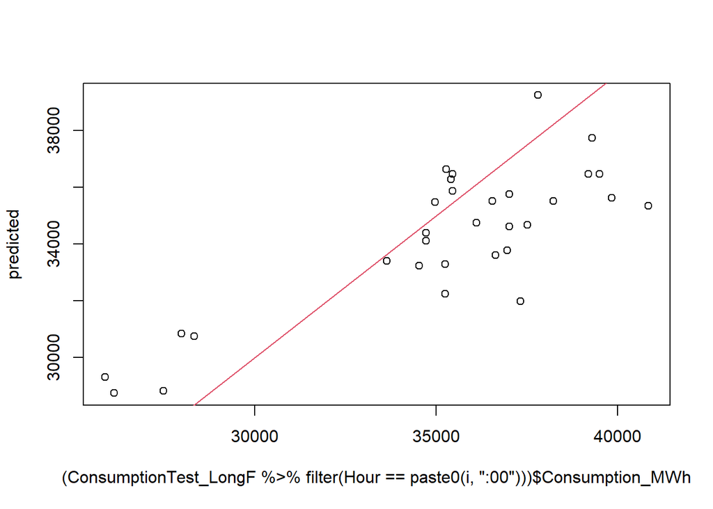

```
## [1] "MAPE of the linear regression for hour 10 is: 0.0631660015745469"
## [1] "Summary of Absolute Percentage Errors for the linear regression when Hour is equal to 10 :"
##     Min.  1st Qu.   Median     Mean  3rd Qu.     Max.
## 0.007163 0.031411 0.055364 0.060890 0.085524 0.142928
```

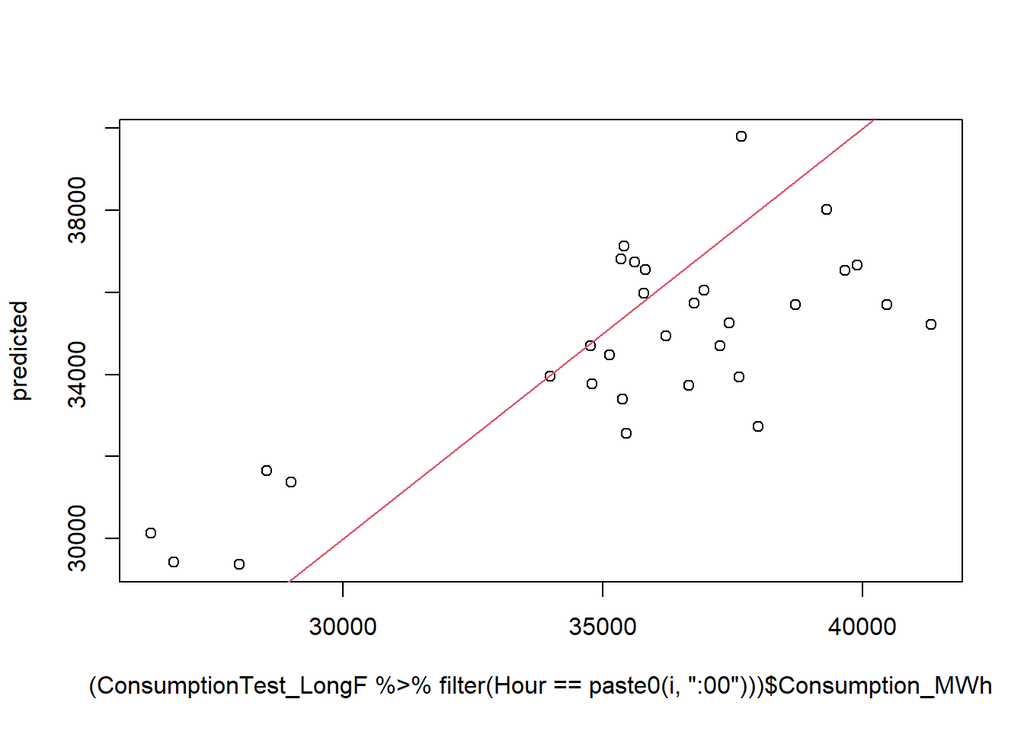

```
## [1] "MAPE of the linear regression for hour 11 is: 0.0650311065148825"
## [1] "Summary of Absolute Percentage Errors for the linear regression when Hour is equal to 11 :"
##      Min.   1st Qu.    Median      Mean   3rd Qu.      Max.
## 0.0005982 0.0305349 0.0564181 0.0627489 0.0815224 0.1478534
```

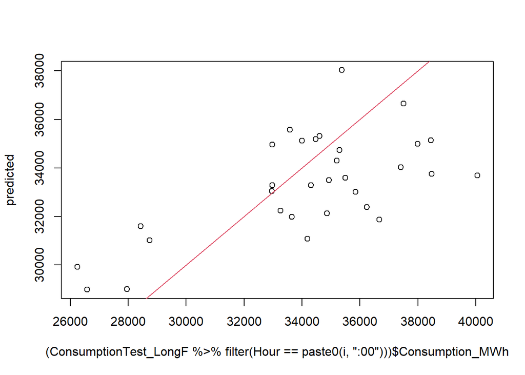

```
## [1] "MAPE of the linear regression for hour 12 is: 0.0680309594813595"
## [1] "Summary of Absolute Percentage Errors for the linear regression when Hour is equal to 12 :"
##     Min.  1st Qu.   Median     Mean  3rd Qu.     Max.
## 0.002714 0.030157 0.060008 0.065448 0.090374 0.158737
```

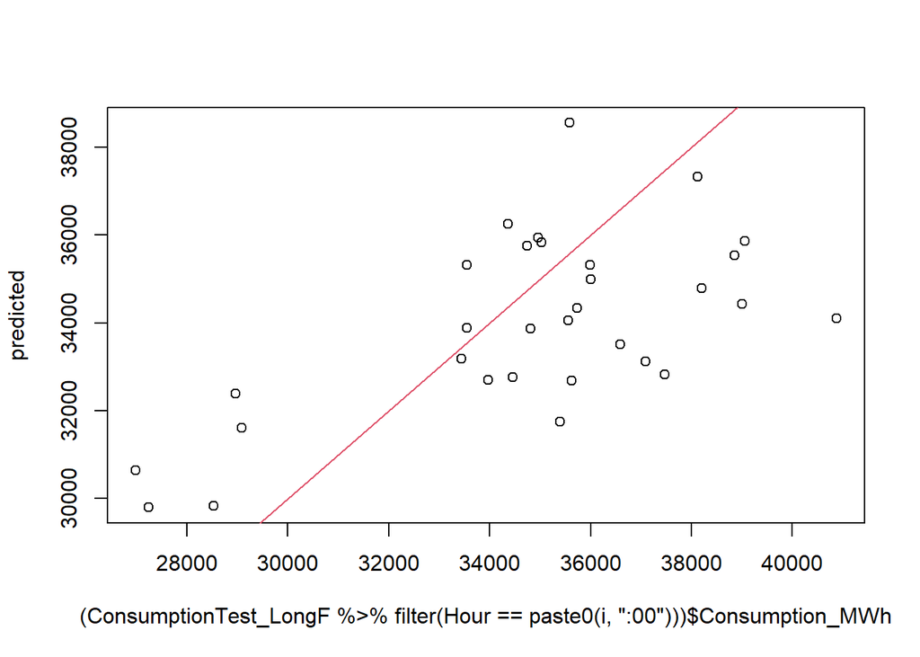

```
## [1] "MAPE of the linear regression for hour 13 is: 0.0694281934650061"
## [1] "Summary of Absolute Percentage Errors for the linear regression when Hour is equal to 13 :"
##     Min.  1st Qu.   Median     Mean  3rd Qu.     Max.
## 0.007718 0.028759 0.055035 0.066853 0.091739 0.165703
```

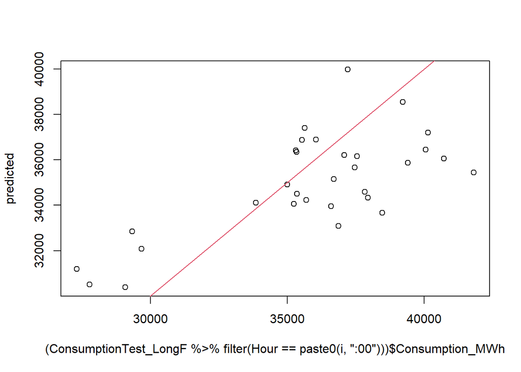

```
## [1] "MAPE of the linear regression for hour 14 is: 0.067118845412495"
## [1] "Summary of Absolute Percentage Errors for the linear regression when Hour is equal to 14 :"
##     Min.  1st Qu.   Median     Mean  3rd Qu.     Max.
## 0.002851 0.032374 0.049482 0.064828 0.092673 0.152381
```

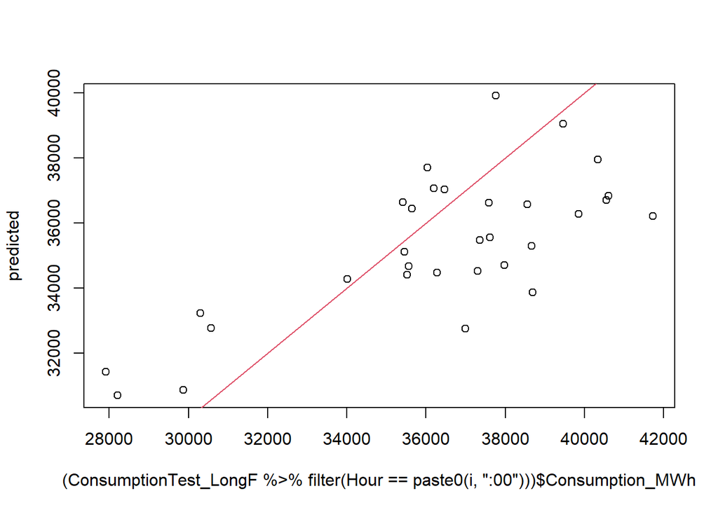

```
## [1] "MAPE of the linear regression for hour 15 is: 0.0633269408377668"
## [1] "Summary of Absolute Percentage Errors for the linear regression when Hour is equal to 15 :"
##     Min.  1st Qu.   Median     Mean  3rd Qu.     Max.
## 0.008022 0.028363 0.054496 0.060844 0.088971 0.131969
```

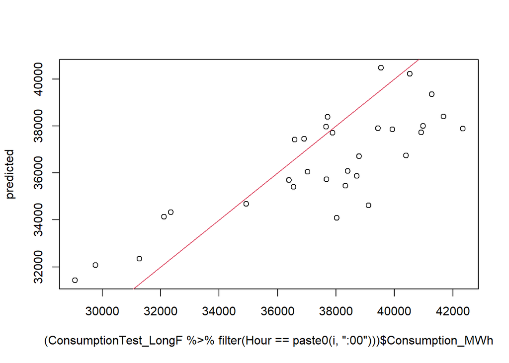

```
## [1] "MAPE of the linear regression for hour 16 is: 0.0539450160705578"
## [1] "Summary of Absolute Percentage Errors for the linear regression when Hour is equal to 16 :"
##     Min.  1st Qu.   Median     Mean  3rd Qu.     Max.
## 0.004497 0.023207 0.051928 0.051487 0.076354 0.114990
```

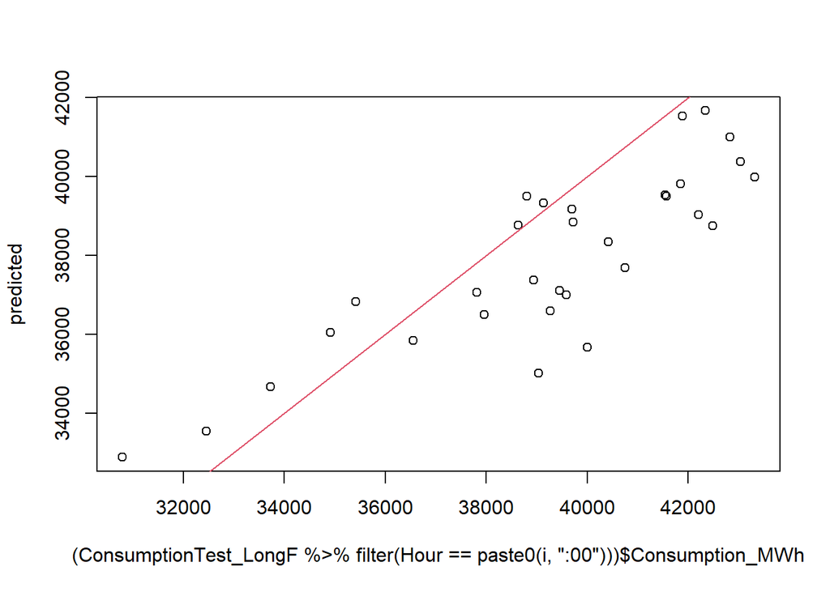

```
## [1] "MAPE of the linear regression for hour 17 is: 0.0486227764992111"
## [1] "Summary of Absolute Percentage Errors for the linear regression when Hour is equal to 17 :"
##     Min.  1st Qu.   Median     Mean  3rd Qu.     Max.
## 0.003571 0.020768 0.042802 0.046109 0.066677 0.108545
```

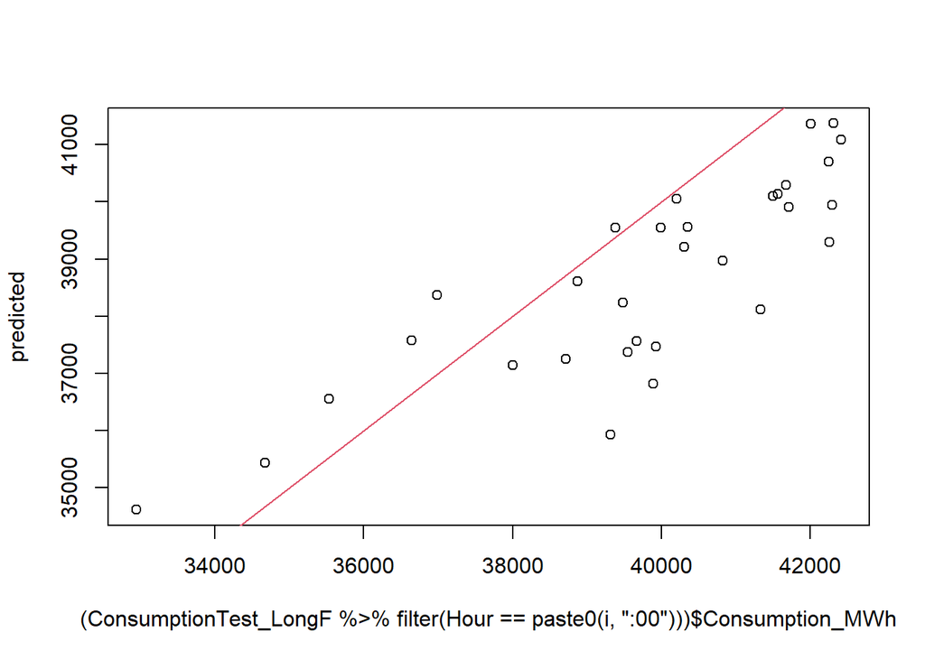

```
## [1] "MAPE of the linear regression for hour 18 is: 0.0389789631113175"
## [1] "Summary of Absolute Percentage Errors for the linear regression when Hour is equal to 18 :"
##     Min.  1st Qu.   Median     Mean  3rd Qu.     Max.
## 0.003647 0.022392 0.033819 0.037390 0.051829 0.086187
```

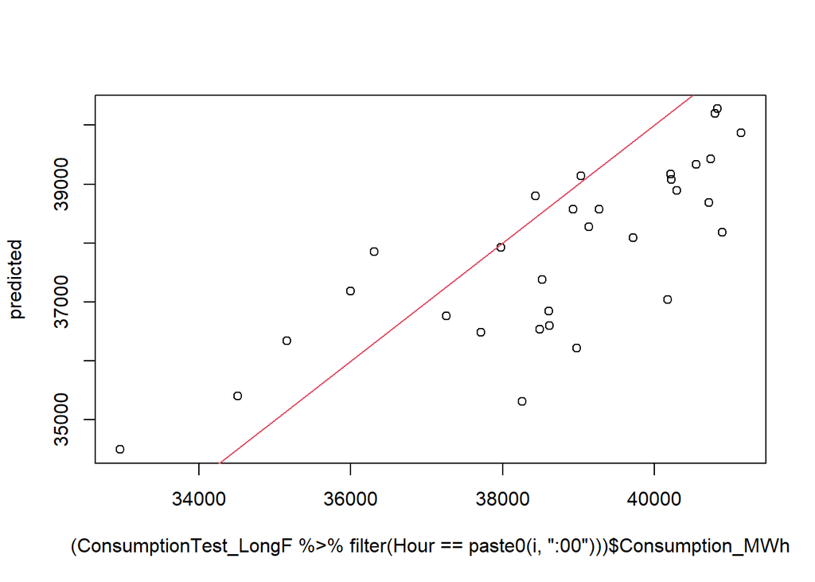

```
## [1] "MAPE of the linear regression for hour 19 is: 0.0355703946238184"
## [1] "Summary of Absolute Percentage Errors for the linear regression when Hour is equal to 19 :"
##     Min.  1st Qu.   Median     Mean  3rd Qu.     Max.
## 0.001513 0.019992 0.032553 0.034346 0.046258 0.078111
```

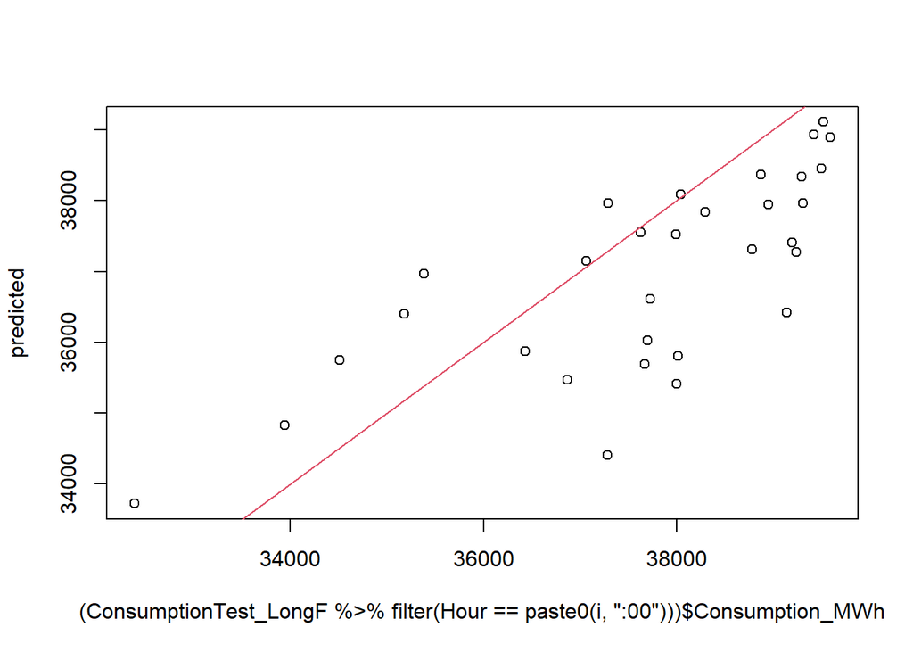

```
## [1] "MAPE of the linear regression for hour 20 is: 0.0326619560363209"
## [1] "Summary of Absolute Percentage Errors for the linear regression when Hour is equal to 20 :"
##    Min. 1st Qu.  Median    Mean 3rd Qu.    Max.
## 0.00121 0.01424 0.02947 0.03164 0.04463 0.07715
```

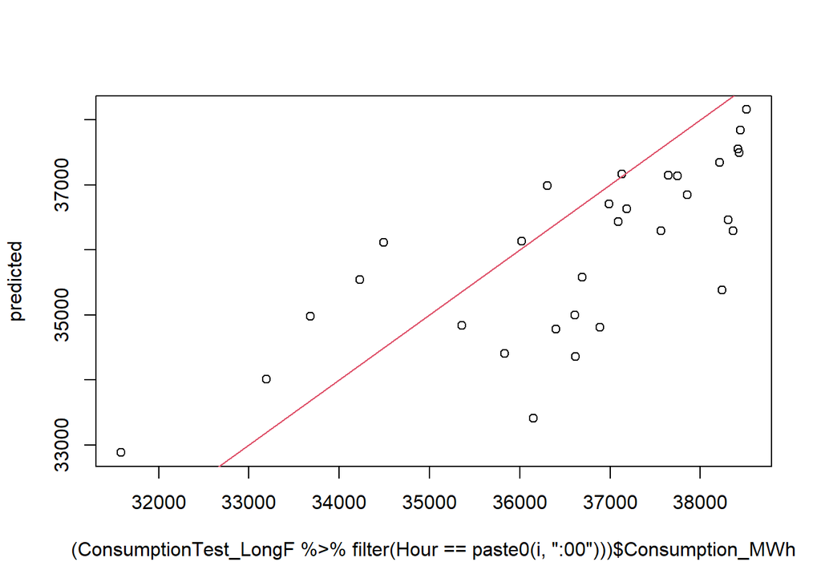

```
## [1] "MAPE of the linear regression for hour 21 is: 0.032616776217264"
## [1] "Summary of Absolute Percentage Errors for the linear regression when Hour is equal to 21 :"
##     Min.  1st Qu.   Median     Mean  3rd Qu.     Max.
## 0.001093 0.015920 0.026645 0.031663 0.044280 0.075910
```

[2 more figures not shown]

```
## [1] "MAPE of the linear regression for hour 23 is: 0.0348747594626344"
## [1] "Summary of Absolute Percentage Errors for the linear regression when Hour is equal to 23 :"
##     Min.  1st Qu.   Median     Mean  3rd Qu.     Max.
## 0.006147 0.019756 0.028710 0.033868 0.046819 0.074669
```

```r
for(i in 10:23){
  fit_lreg=lm(Consumption_MWh~lag_48+lag_168,
              ConsumptionTrain_LongF[169:42384,]%>%filter(Hour==paste0(i,":00")))
  #print(summary(fit_lreg))
  predicted=predict(fit_lreg,
                    ConsumptionTest_LongF%>%filter(Hour==paste0(i,":00")))
  plot((ConsumptionTest_LongF%>%filter(Hour==paste0(i,":00")))$Consumption_MWh,predicted)
  abline(a=0,b=1,col=2)
  MAPE_lreg<-append(MAPE_lreg,MAPE((ConsumptionTest_LongF%>%filter(Hour==paste0(i,":00")))$Consumption_MWh,predicted))
  print(paste("MAPE of the linear regression for hour",i,"is:",MAPE_lreg[i+1]))

  actual<-(ConsumptionTest_LongF%>%filter(Hour==paste0(i,":00")))$Consumption_MWh
  residual<-(ConsumptionTest_LongF%>%filter(Hour==paste0(i,":00")))$Consumption_MWh-predicted
  AbsPercError<-abs(residual/actual)
  print(paste("Summary of Absolute Percentage Errors for the linear regression when Hour is equal to",i,":"))
  print(summary(AbsPercError))
  APE_lreg<-append(APE_lreg, AbsPercError)
}
```

```r
 print("Summary of MAPE for the hourly linear regression:")
```

```
## [1] "Summary of MAPE for the hourly linear regression:"
```

```r
 print(summary(MAPE_lreg))
```

```
##    Min. 1st Qu.  Median    Mean 3rd Qu.    Max.
## 0.03261 0.03277 0.03727 0.04514 0.05860 0.06943
```

Comparing the performance of models applied to time zones, it is seen that less error occurs at night. MAPE values are higher for hours from 8 am to 5 pm.